# Activity: Nuclear Reactors

Nandagopal Panicker

```r
library(tidyverse)
```

## Scrape the Data

```r
library(rvest)

page <- "https://en.wikipedia.org/wiki/List_of_commercial_nuclear_reactors"
tableList <- page %>%
  read_html() %>%
  html_nodes(css = "table") %>%
  html_table(fill = TRUE)
```

[output not shown]

```r
head(tableList[[21]])
```

| Plantname | UnitNo. | Type | Model | Status | Capacity(MW) | Beginbuilding | Commercialoperation | Closed |
| --- | --- | --- | --- | --- | --- | --- | --- | --- |
| Fugen | 1 | HWLWR | ATR | Shut down | 148 | 10 May 1972 | 20 Mar 1979 | 29 Mar 2003 |
| Fukushima Daiichi | 1 | BWR | BWR-3 | Inoperable | 439 | 25 Jul 1967 | 26 Mar 1971 | 19 May 2011 |
| Fukushima Daiichi | 2 | BWR | BWR-4 | Inoperable | 760 | 9 Jun 1969 | 18 Jul 1974 | 19 May 2011 |
| Fukushima Daiichi | 3 | BWR | BWR-4 | Inoperable | 760 | 28 Dec 1970 | 27 Mar 1976 | 19 May 2011 |
| Fukushima Daiichi | 4 | BWR | BWR-4 | Inoperable | 760 | 12 Feb 1973 | 12 Oct 1978 | 19 May 2011 |
| Fukushima Daiichi | 5 | BWR | BWR-4 | Shut down | 760 | 22 May 1972 | 18 Apr 1978 | 17 Dec 2013 |

## Your turn: In what ways is the table tidy? How is it not tidy? What’s different about it from a tidy table?

The table is tidy cause each row contains a distinct observation about a specific unit of a nuclear power plant and each column represents a single variable such as ‘Plant Name’. For power plants with multiple units, the Plant name is repeated in multiple rows this can be circumvented. In addition to this, there seems to be a lot of plain missing data. Also, the dates need to be converted to numeric format and the missing data needs to be filled in with N/A which is reccurent for currently operational plants.Lastly, the superscripts attribute to possible errors during data visualization since they make for new categories in certain variables for eg: i) Operational ii) Operational[81]. There are ways to make this table less redundant .

## Your Turn: Plot Net Generation Capacity vs Construction Date

```r
japan <- tableList[[21]]
str(japan)
```

```
tibble [62 × 9] (S3: tbl_df/tbl/data.frame)
 $ Plantname          : chr [1:62] "Fugen" "Fukushima Daiichi" "Fukushima Daiichi" "Fukushima Daiichi" ...
 $ UnitNo.            : int [1:62] 1 1 2 3 4 5 6 1 2 3 ...
 $ Type               : chr [1:62] "HWLWR" "BWR" "BWR" "BWR" ...
 $ Model              : chr [1:62] "ATR" "BWR-3" "BWR-4" "BWR-4" ...
 $ Status             : chr [1:62] "Shut down" "Inoperable" "Inoperable" "Inoperable" ...
 $ Capacity(MW)       : int [1:62] 148 439 760 760 760 760 1067 1067 1067 1067 ...
 $ Beginbuilding      : chr [1:62] "10 May 1972" "25 Jul 1967" "9 Jun 1969" "28 Dec 1970" ...
 $ Commercialoperation: chr [1:62] "20 Mar 1979" "26 Mar 1971" "18 Jul 1974" "27 Mar 1976" ...
 $ Closed             : chr [1:62] "29 Mar 2003" "19 May 2011" "19 May 2011" "19 May 2011" ...
```

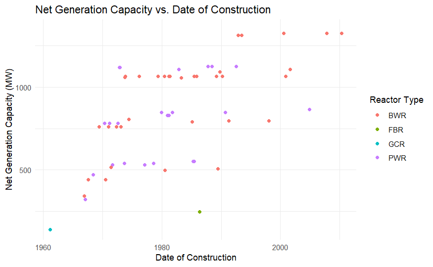

```r
japan <-
  japan %>%
  filter(row_number() > 1) %>%
  rename(name = Plantname,
         reactor = `UnitNo.`,
         type = Type,
         model = Model,
         status = Status,
         netMW = `Capacity(MW)`,
         construction = `Beginbuilding`,
         operation = `Commercialoperation`,
         closure = Closed)

japan <- japan %>%
  mutate(
    construction = dmy(construction),
    operation = dmy(operation),
    closure = dmy(closure)
  )
ggplot(japan, aes(x = construction, y = netMW, color = type)) +
  geom_point() +
  labs(
    title = "Net Generation Capacity vs. Date of Construction",
    x = "Date of Construction",
    y = "Net Generation Capacity (MW)",
    color = "Reactor Type"
  ) +
  theme_minimal()
```

## Your Turn: Scrape & Clean China Data (then merge with Japan)

```r
china <- tableList[[10]]
head(china)
```

| Plantname | UnitNo. | Type | Model | Status | Capacity(MW) | Beginbuilding | Commercialoperation | Closed |
| --- | --- | --- | --- | --- | --- | --- | --- | --- |
| Bailong | 1 | PWR | CAP-1000 | Planned | 1100 |  |  | NA |
| Bailong | 2 | PWR | CAP-1000 | Planned | 1100 |  |  | NA |
| Changjiang | I-1 | PWR | CNP-600 | Operational | 601 | 25 Apr 2010 | 25 Dec 2015 | NA |
| Changjiang | I-2 | PWR | CNP-600 | Operational | 601 | 21 Nov 2010 | 20 Jun 2016 | NA |
| Changjiang | I-3[25] | PWR | Hualong One | Under construction | 1200 | 31 Mar 2021[26] |  | NA |
| Changjiang | I-4[25] | PWR | Hualong One | Under construction | 1200 | 31 Mar 2021[26] |  | NA |

```r
china <- china %>%
  filter(row_number() > 1) %>%
  rename(
    name = Plantname,
    reactor = `UnitNo.`,
    type = Type,
    model = Model,
    status = Status,
    netMW = `Capacity(MW)`,
    construction = `Beginbuilding`,
    operation = `Commercialoperation`,
    closure = Closed
  ) %>%
  mutate(
    construction = dmy(construction),
    operation = dmy(operation),
    closure = dmy(closure)
  )
```

Merging the data:

```r
japan <- japan %>%
  mutate(reactor = as.character(reactor))

china <- china %>%
  mutate(reactor = as.character(reactor))

japan <- japan %>%
  mutate(country = "Japan")

china <- china %>%
  mutate(country = "China")

combined_data <- bind_rows(japan, china)

combined_data
```

| name | reactor | type | model | status | netMW | construction | operation | closure | country |
| --- | --- | --- | --- | --- | --- | --- | --- | --- | --- |
| Fukushima Daiichi | 1 | BWR | BWR-3 | Inoperable | 439 | 1967-07-25 | 1971-03-26 | 2011-05-19 | Japan |
| Fukushima Daiichi | 2 | BWR | BWR-4 | Inoperable | 760 | 1969-06-09 | 1974-07-18 | 2011-05-19 | Japan |
| Fukushima Daiichi | 3 | BWR | BWR-4 | Inoperable | 760 | 1970-12-28 | 1976-03-27 | 2011-05-19 | Japan |
| Fukushima Daiichi | 4 | BWR | BWR-4 | Inoperable | 760 | 1973-02-12 | 1978-10-12 | 2011-05-19 | Japan |
| Fukushima Daiichi | 5 | BWR | BWR-4 | Shut down | 760 | 1972-05-22 | 1978-04-18 | 2013-12-17 | Japan |
| Fukushima Daiichi | 6 | BWR | BWR-5 | Shut down | 1067 | 1973-10-26 | 1979-10-24 | 2013-12-17 | Japan |
| Fukushima Daini | 1 | BWR | BWR-5 | Shut down | 1067 | 1976-03-16 | 1982-04-20 | 2019-09-30 | Japan |
| Fukushima Daini | 2 | BWR | BWR-5 | Shut down | 1067 | 1979-05-25 | 1984-02-03 | 2019-09-30 | Japan |
| Fukushima Daini | 3 | BWR | BWR-5 | Shut down | 1067 | 1981-03-23 | 1985-06-21 | 2019-09-30 | Japan |
| Fukushima Daini | 4 | BWR | BWR-5 | Shut down | 1067 | 1981-05-28 | 1987-08-25 | 2019-09-30 | Japan |

[output cut: 166 more lines]

## Your Turn: Reconstruct Info Graphic of Japan Reactors (or other country of interest)

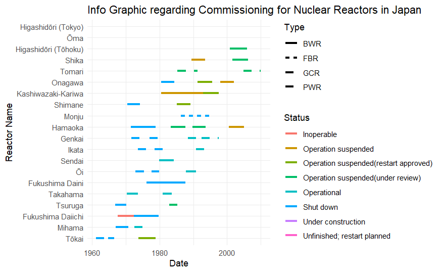

```r
japan_data <- combined_data %>%
  filter(country == "Japan") %>%
  mutate(
    duration = as.numeric(difftime(operation, construction, units = "days"))
  )
japan_data <- japan_data %>%
  mutate(
    status = str_replace_all(status, "\\[.*?\\]", "")
  )



ggplot(japan_data, aes(y = reorder(name, construction), x = construction, xend = operation, color = status, linetype = type)) +
  geom_segment(aes(xend = operation), size = 1.2) +
  labs(
    title = "Info Graphic regarding Commissioning for Nuclear Reactors in Japan",
    x = "Date",
    y = "Reactor Name",
    color = "Status",
    linetype = "Type"
  ) +
  theme_minimal() +
  guides(
    color = guide_legend(title = "Status"),
    linetype = guide_legend(title = "Type")
  )
```